# Change in Mean Cell-Type Proportion vs. Control

dpnvisium reproduction of the Science-submission lollipop chart, on new production deconvolution data

## What this reproduces

This regenerates the lollipop chart from `MLC plots--ISH_DPN.Rmd` / `MLC plots--NO_NGN_FINAL.Rmd` (in `ishdpn/MLC.zip`) — “Change in Mean Cell-Type Proportion vs. Non-DPN Neuronal Barcodes” — a chart previously presented in a Science submission — using our new production `dpnvisium` deconvolution output instead of the legacy run.

The statistical method and plotting code below are ported **essentially verbatim** from the original (same spot-pooled mean/95% CI, same delta formula, same colors/theme/dimensions), per explicit instruction: this needs to be a faithful follow-up figure, not a redesign. Only the data loading changed, because our pipeline produces CSVs rather than a single Seurat object with proportions already embedded in `meta.data`.

Two variants are rendered, both from the same underlying code path:

- **WITH_NGN** — matches `delta_means_vs_control--GEO_W_NGN--LOOKS_GREAT.png` (3 groups: NGN, NGN Adjacent, Non-NGN Adjacent)
- **NO_NGN** — matches `delta_means_vs_control--NO_NGN.png` (2 groups: NGN Adjacent, Non-NGN Adjacent)

## 1. Load data

```r
# New production deconvolution output (this session's run)
abundance_path <- "/home/mwild/dpnvisium_dev/production_run_output/cell2location_q05_cell_abundance_w_sf.csv"
# Legacy per-spot NGN/neuron classification, extracted once from Khadijah's
# vis_barcodes 1.rds via extract_legacy_classification.R (see that script)
classification_path <- "data/legacy_dpn_classification.csv"

abundance_raw <- read_csv(abundance_path, show_col_types = FALSE)
classification <- read_csv(classification_path, show_col_types = FALSE)

cat("Abundance rows (spots):", nrow(abundance_raw), "\n")
```

```
## Abundance rows (spots): 40599
```

```r
cat("Classification rows (spots):", nrow(classification), "\n")
```

```
## Classification rows (spots): 40599
```

## 2. Harmonize spot IDs and cell-type names, join

Our spot IDs are `{sample}_{barcode}` (from `dpnvisium.py`’s `read_and_qc`); the legacy classification has `sample` and `barcode` as separate columns — split ours to match. Our abundance columns are prefixed (`q05cell_abundance_w_sf_...`) and have `/` sanitized to `_` (a fix made earlier this session for HDF5 compatibility); the legacy object used the original unsanitized names. Reversing that sanitization (`_` back to `/` for the 7 affected names) would be ambiguous, since `_` also appears in genuinely non-slash names (e.g. `Schwann_1`) — so harmonize the other direction instead: sanitize the legacy names the same way ours already are.

```r
spot_ids <- abundance_raw[[1]]
sample_id <- sub("_.*$", "", spot_ids)
barcode <- sub("^[^_]+_", "", spot_ids)

abundance <- abundance_raw %>%
  rename(spot_id = 1) %>%
  mutate(sample = sample_id, barcode = barcode) %>%
  rename_with(~ sub("^q05cell_abundance_w_sf_", "", .x), starts_with("q05cell_abundance_w_sf_"))

# harmonize legacy cell-type-name columns the same way dpnvisium.py sanitizes: '/' -> '_'
classification <- classification %>%
  mutate(DPN.type = `DPN.type`)  # keep as-is; DPN.type values have no slashes

joined <- abundance %>%
  inner_join(classification, by = c("sample", "barcode"))

join_rate <- nrow(joined) / nrow(abundance) * 100
cat(sprintf("Joined %d / %d spots (%.1f%%) to a legacy classification\n",
            nrow(joined), nrow(abundance), join_rate))
```

```
## Joined 40599 / 40599 spots (100.0%) to a legacy classification
```

```r
print(table(joined$DPN.type, useNA = "always"))
```

```
##
##         DPN_Neu.Mult DPN_Neu.Mult.NearNGN          DPN_Neu.NGN
##                  918                  145                  105
##         DPN_Neu.Sing DPN_Neu.Sing.NearNGN              DPN_NGN
##                 2436                  779                  963
##            DPN_other          No_Neu.Mult          No_Neu.Sing
##                20171                 1460                 2159
##             No_other                 <NA>
##                11463                    0
```

## 3. Cell-type groups (fiber class), exact from the original

```r
yellow_subtypes <- c(
  "A-LTMR.TAC3", "A-Propr.EPHA3", "A-Propr.HAPLN4", "A-Propr.PCDH8",
  "Ab-LTMR.CCKAR", "Ab-LTMR.ETV1", "Ab-LTMR.LGI2", "Ab-LTMR.NSG2"
)
cyan_subtypes <- c("A-PEP.SCGN_ADRA2C", "A-PEP.CHRNA7_SLC18A3", "A-PEP.KIT", "A-PEP.NTRK3_S100A16")
green_subtypes <- c("C-LTMR.CDH9", "C-NP.SST", "C-NP.MRGPRX1_GFRA2", "C-NP.MRGPRX1_MRGPRX4")
magenta_subtypes <- c("C-PEP.ADORA2B", "C-PEP.TAC1_CACNG5", "C-PEP.TAC1_CHRNA3", "C-Thermo.RXFP1", "C-Thermo.TRPM8")

all_nocis_expected <- c(cyan_subtypes, yellow_subtypes, green_subtypes, magenta_subtypes)
missing_types <- setdiff(all_nocis_expected, colnames(joined))
all_nocis <- intersect(all_nocis_expected, colnames(joined))

if (length(missing_types) > 0) {
  cat(sprintf(
    "NOTE: %d of %d expected cell types are absent from this reference and will not appear below: %s\n",
    length(missing_types), length(all_nocis_expected), paste(missing_types, collapse = ", ")
  ))
} else {
  cat("All expected cell types present.\n")
}
```

```
## All expected cell types present.
```

```r
group_df_base <- tibble(
  CellType = c(yellow_subtypes, cyan_subtypes, green_subtypes, magenta_subtypes),
  Group = c(
    rep("A-LTMRs", length(yellow_subtypes)),
    rep("A-NOCs", length(cyan_subtypes)),
    rep("C-NPs", length(green_subtypes)),
    rep("C-PEPs", length(magenta_subtypes))
  )
) %>%
  filter(CellType %in% all_nocis) %>%
  mutate(CellType = factor(CellType, levels = all_nocis)) %>%
  arrange(CellType) %>%
  mutate(y = row_number())
```

## 4. Statistic: spot-pooled mean, 95% CI, delta vs. control

```r
keep_types <- c("No_Neu.Sing", "DPN_NGN", "DPN_Neu.Sing", "DPN_Neu.Sing.NearNGN")

md <- joined %>% filter(DPN.type %in% keep_types)

md_long <- md %>%
  pivot_longer(cols = all_of(all_nocis), names_to = "CellType", values_to = "Proportion")

md_summary <- md_long %>%
  group_by(DPN.type, CellType) %>%
  summarize(
    mean = mean(Proportion, na.rm = TRUE),
    sd = sd(Proportion, na.rm = TRUE),
    n = n(),
    se = sd / sqrt(n),
    lower = mean - 1.96 * se,
    upper = mean + 1.96 * se,
    .groups = "drop"
  )

baseline <- md_summary %>%
  filter(DPN.type == "No_Neu.Sing") %>%
  select(CellType, baseline_mean = mean)

delta_df_full <- md_summary %>%
  left_join(baseline, by = "CellType") %>%
  filter(DPN.type != "No_Neu.Sing") %>%
  mutate(
    delta = mean / baseline_mean,
    delta_lower = lower / baseline_mean,
    delta_upper = upper / baseline_mean,
    CellType = factor(CellType, levels = all_nocis)
  )
```

## 5. Plot function (verbatim port of `p_delta`, parameterized on NGN inclusion)

```r
make_lollipop <- function(delta_df, group_df, include_ngn = TRUE) {
  if (include_ngn) {
    plot_df <- delta_df
    color_values <- c("DPN_Neu.Sing" = "#228B22", "DPN_Neu.Sing.NearNGN" = "#007FFF", "DPN_NGN" = "#8849A6")
    color_labels <- c("DPN_Neu.Sing.NearNGN" = "NGN Adjacent", "DPN_Neu.Sing" = "Non-NGN Adjacent", "DPN_NGN" = "NGN")
    color_limits <- c("DPN_Neu.Sing.NearNGN", "DPN_Neu.Sing", "DPN_NGN")
  } else {
    plot_df <- delta_df %>% filter(DPN.type != "DPN_NGN")
    color_values <- c("DPN_Neu.Sing" = "#228B22", "DPN_Neu.Sing.NearNGN" = "#007FFF")
    color_labels <- c("DPN_Neu.Sing.NearNGN" = "NGN Adjacent", "DPN_Neu.Sing" = "Non-NGN Adjacent")
    color_limits <- c("DPN_Neu.Sing.NearNGN", "DPN_Neu.Sing")
  }

  p <- ggplot(plot_df, aes(x = delta, y = CellType, color = DPN.type)) +
    geom_vline(xintercept = 1, linetype = "dashed", linewidth = 0.4) +
    geom_point(size = 2) +
    geom_errorbarh(aes(xmin = delta_lower, xmax = delta_upper), height = 0.25) +
    scale_color_manual(values = color_values, labels = color_labels, limits = color_limits) +
    labs(
      title = "            Change in Mean Cell-Type Proportion",
      x = "Fold-Change in Mean Proportion \nvs. Non-DPN Neuronal Barcodes",
      y = "Cell Type",
      color = "Neuon Type"
    ) +
    # NOTE: the original never applies scale_fill_manual to this chart (the
    # `group_colors` palette it defines elsewhere is only used on the ridge
    # plot) -- these bands use ggplot2's default discrete fill palette.
    # Reproduced as-is, not "fixed", for exact visual parity.
    geom_rect(
      data = group_df,
      aes(xmin = -Inf, xmax = Inf, ymin = y - .5, ymax = y + .5, fill = Group),
      alpha = 0.25,
      inherit.aes = FALSE
    ) +
    theme_minimal(base_size = 14) +
    theme(
      legend.position = "bottom",
      legend.justification = "left",
      legend.box.just = "left",
      legend.direction = "horizontal",
      legend.key.height = unit(0.6, "cm"),
      legend.key.width  = unit(1.2, "cm"),
      legend.box = "vertical",
      legend.title = element_text(size = 10, hjust = 0),
      legend.text  = element_text(size = 9, hjust = 0),
      plot.title = element_text(face = "bold", size = 15, hjust = 1.25),
      axis.title.x = element_text(size = 12, hjust = .2),
      axis.title.y = element_text(size = 12),
      panel.grid.major.y = element_blank(),
      panel.grid.minor = element_blank(),
      axis.text.y = element_text(size = 10)
    ) +
    guides(color = guide_legend(order = 1, nrow = 1), fill = guide_legend(order = 2, nrow = 1))

  p <- p + theme(
    legend.position = c(0.02, -0.05),
    legend.direction = "horizontal",
    legend.box.just = "left",
    legend.justification = c(.45, 1.25),
    plot.margin = unit(c(1, 1, 3, 1), "cm"),
    legend.key.height = unit(0.6, "cm"),
    legend.key.width  = unit(1.2, "cm")
  )
  p
}
```

## 6. Render and save both variants

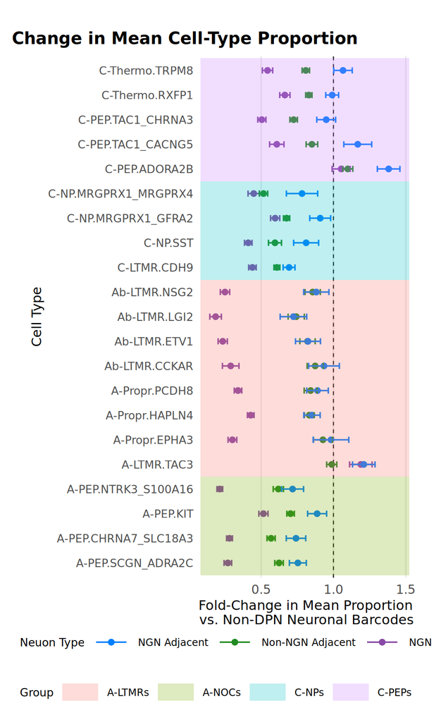

```r
p_with_ngn <- make_lollipop(delta_df_full, group_df_base, include_ngn = TRUE)
ggsave("delta_means_vs_control--WITH_NGN--dpnvisium.pdf", p_with_ngn, width = 5.5, height = 9, dpi = 300)
ggsave("delta_means_vs_control--WITH_NGN--dpnvisium.png", p_with_ngn, width = 5.5, height = 9, dpi = 300)
p_with_ngn
```

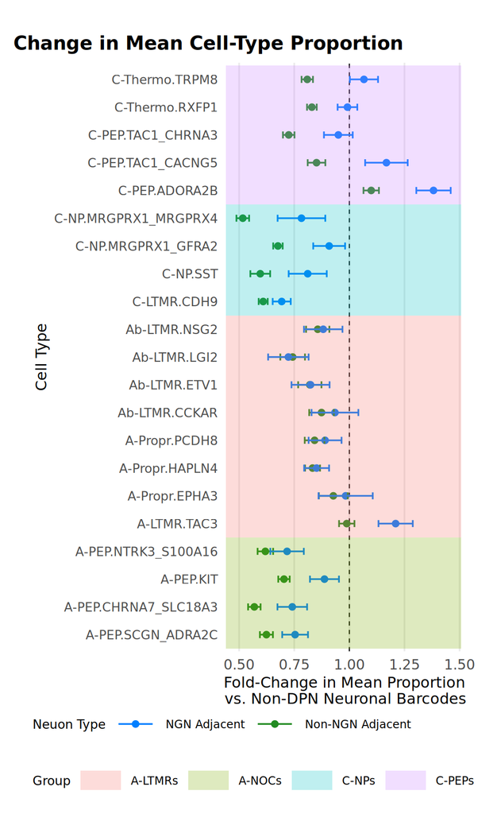

```r
p_no_ngn <- make_lollipop(delta_df_full, group_df_base, include_ngn = FALSE)
ggsave("delta_means_vs_control--NO_NGN--dpnvisium.pdf", p_no_ngn, width = 5.5, height = 9, dpi = 300)
ggsave("delta_means_vs_control--NO_NGN--dpnvisium.png", p_no_ngn, width = 5.5, height = 9, dpi = 300)
p_no_ngn
```